# Notes-Chapter2

The Caveman Coder

2025-12-29

# Chapter 2: Spatial data and R packages for mapping

## Types of spatial data

- **areal data:** data domain is partitioned to a finite number of areal units. Examples: attributes collected by ZIP code, or remotely-sensed data reported by pixels.
- **geostatistical data:** the domain is a continuous fixed set.
- **point patterns:** data domain is random.

Example of areal data:

```r
library(sf)
```

```r
library(ggplot2)
library(viridis)
nc <- st_read(
  system.file("shape/nc.shp", package = "sf"),
  quiet = TRUE
)

head(nc)
```

```
## Simple feature collection with 6 features and 14 fields
## Geometry type: MULTIPOLYGON
## Dimension:     XY
## Bounding box:  xmin: -81.74107 ymin: 36.07282 xmax: -75.77316 ymax: 36.58965
## Geodetic CRS:  NAD27
##    AREA PERIMETER CNTY_ CNTY_ID        NAME  FIPS FIPSNO CRESS_ID BIR74 SID74
## 1 0.114     1.442  1825    1825        Ashe 37009  37009        5  1091     1
## 2 0.061     1.231  1827    1827   Alleghany 37005  37005        3   487     0
## 3 0.143     1.630  1828    1828       Surry 37171  37171       86  3188     5
## 4 0.070     2.968  1831    1831   Currituck 37053  37053       27   508     1
## 5 0.153     2.206  1832    1832 Northampton 37131  37131       66  1421     9
## 6 0.097     1.670  1833    1833    Hertford 37091  37091       46  1452     7
##   NWBIR74 BIR79 SID79 NWBIR79                       geometry
## 1      10  1364     0      19 MULTIPOLYGON (((-81.47276 3...
## 2      10   542     3      12 MULTIPOLYGON (((-81.23989 3...
## 3     208  3616     6     260 MULTIPOLYGON (((-80.45634 3...
## 4     123   830     2     145 MULTIPOLYGON (((-76.00897 3...
## 5    1066  1606     3    1197 MULTIPOLYGON (((-77.21767 3...
## 6     954  1838     5    1237 MULTIPOLYGON (((-76.74506 3...
```

Plot of the example areal data:

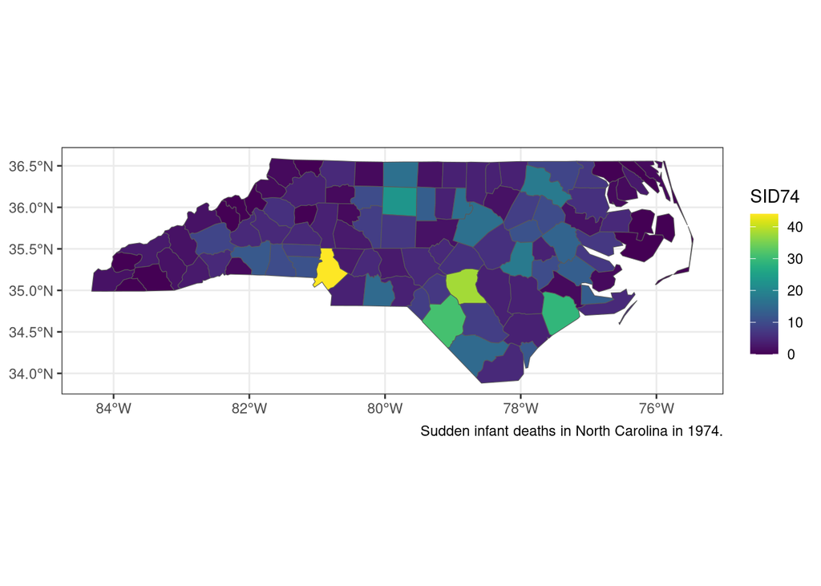

```r
ggplot(
  data = nc,
  aes(fill = SID74)
) +
  geom_sf() +
  scale_fill_viridis() +
  theme_bw() +
  labs(
    caption = "Sudden infant deaths in North Carolina in 1974."
  )
```

Example of geostatistical data:

```r
library(geoR)
library(dplyr)
glimpse(parana)
```

```
## List of 4
##  $ east              , north             : num [1:143, 1:2] 403 502 556 573 702 ...
##   ..- attr(*, "dimnames")=List of 2
##   .. ..$ : NULL
##   .. ..$ : chr [1:2] "east" "north"
##  $ data              : num [1:143] 306 201 167 163 164 ...
##  $ borders           : num [1:369, 1:2] 670 664 656 650 643 ...
##   ..- attr(*, "dimnames")=List of 2
##   .. ..$ : NULL
##   .. ..$ : chr [1:2] "east" "north"
##  $ loci.paper        : num [1:4, 1:2] 300 648 362 410 484 ...
##  - attr(*, "class")= chr "geodata"
```

```r
head(parana, 5)
```

```
## $coords
##            east     north
##   [1,] 402.9529 164.52841
##   [2,] 501.7049 428.77100
##   [3,] 556.3262 445.27065
##   [4,] 573.4043 447.04177
##   [5,] 702.4228 272.29590
##   [6,] 668.5442 261.67070
##   [7,] 435.8477 286.54044
##   [8,] 434.0125 317.90506
##   [9,] 432.4622 288.37001
##  [10,] 162.1458 286.29984
##  [11,] 169.4766 334.53158
##  [12,] 717.8468 181.56741
##  [13,] 713.3433 214.88336
```

[output cut: 526 more lines]

Plot of the example geostatistical data:

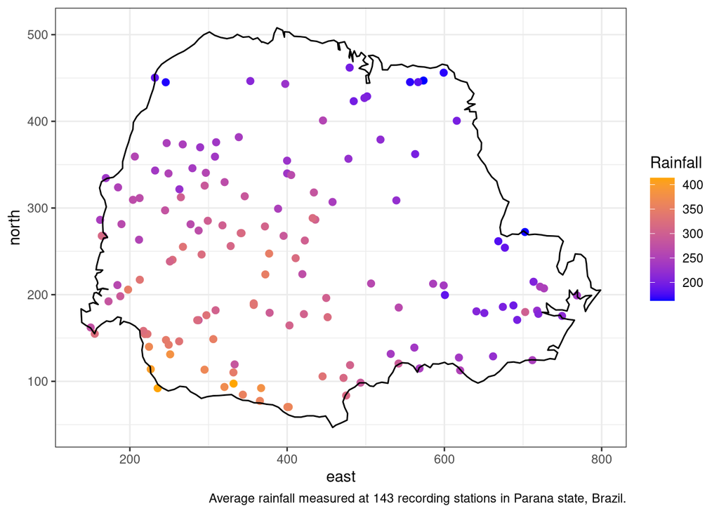

```r
ggplot(
  data.frame(cbind(parana$coords, Rainfall = parana$data))
) +
  geom_point(
    aes(east, north, color = Rainfall),
    size = 2
  ) +
  scale_color_gradient(low = "blue", high = "orange") +
  geom_path(
    data = data.frame(parana$border),
    aes(east, north)
  ) +
  theme_bw() +
  labs(
    caption = "Average rainfall measured at 143 recording stations in Parana state, Brazil."
  )
```

Example of point patterns:

```r
library(cholera)

head(fatalities)
```

```
##   case         x         y        lon      lat
## 1    1 13.588010 11.095600 -0.1358083 51.51301
## 2    2  9.878124 12.559180 -0.1387260 51.51376
## 3    3 14.653980 10.180440 -0.1349428 51.51257
## 4    4 15.220570  9.993003 -0.1344891 51.51248
## 5    5 13.162650 12.963190 -0.1360806 51.51394
## 6    6 13.806170  8.889046 -0.1356408 51.51194
```

Plot of the example point patterns:

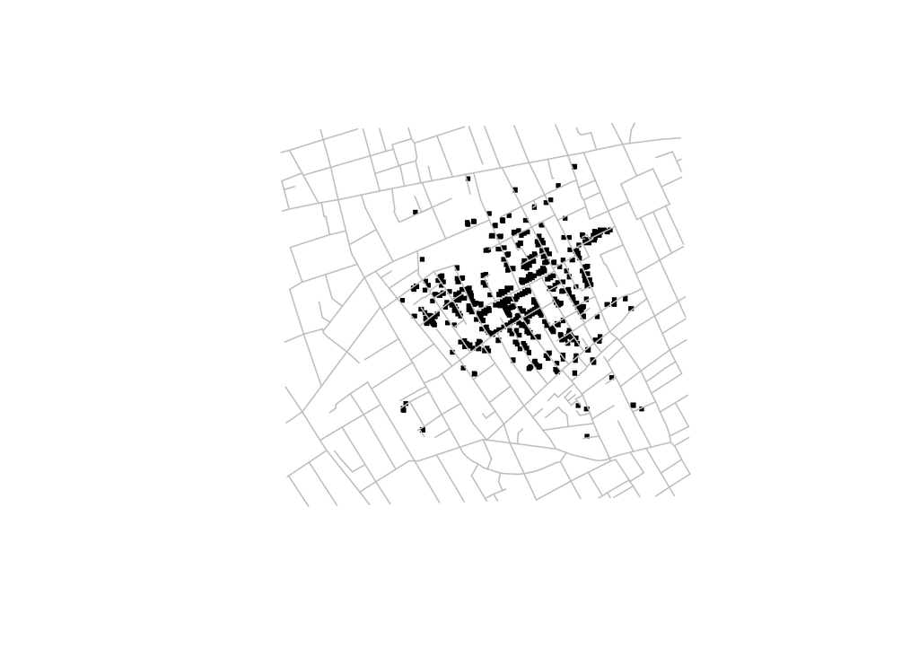

```r
rng <- mapRange()

plot(fatalities[, c("x", "y")],
     pch = 15, col = "black",
     cex = 0.5,
     xlim = rng$x,
     ylim = rng$y,
     asp = 1,
     frame.plot = FALSE,
     axes = FALSE,
     xlab = "", ylab = ""
)
addRoads()
```

John Snow’s map of the 1854 London cholera outbreak.

## Coordinate reference systems

Locations on Earth can be referenced using unprojected (or geographic) or projected coordinate reference systems.  
- Unprojected/geographic reference systems use longitude and latitude for referencing a location on the Earth’s 3d surface.  
- Projected coordinate reference systems use easting northing Cartesian coordinates for referencing a location on a 2d representation of the Earth

### Geographic coordinate systems

- Latitude and longitude are angles given in decimal degrees (DM) or in degrees, minutes, seconds (DMS).
- The prime meridian passes through the British Royal Observatory in Greenwich, England.
- The prime meridian determines the eastern and western hemispheres.  
  Longitude values range from -180 degrees when running west to 180 degrees when running east.

### Projected coordinate systems

Since a map projection is a transformation of the Earth’s 3d surface as a flat, 2d plane, all map projections distort the Earth’s surface in some way.

The Mercator projection preserves local angles and shapes (useful in navigation especially during the Age of Exploration), but distorts the land area.

- A variant of the original Mercator projection, called the Universal Transverse Mercator (UTM), divides the Earth into 60 zones of 6 degrees of longitude in width.
- Each of the zones uses a transverse Mercator projection that maps a region of large north-south extent.
- A position on Earth is givben by the UTM zone number, the hemisphere, and the easting and northing coordinates in the zone, measured in meters.

### Setting Coordinate Reference Systems in R

- The Earth’s shape is not a perfect sphere. It is an oblate spheroid that bulges at the equator and is flattened at the poles.
- The most common reference ellipsoid in use is called WGS84 or World Geodetic System.
- WGS84 is used by the Global Positioning System (GPS).
- The position of the model ellipsoid relative to the center of the Earth defined by the **datum**. The datum provides the origin point and defines the direction of the coordinate axes.

Script that defines the WGS84 longitude/latitude projection in R:

```r
"+proj=longlat +ellps=WGS84 +datum=WGS84 +no_defs"
```

Another common reference system is the one used by the European Petroleum Survey Group and is known as the EPSG code.  
- The EPSG equivalent of WGS84 projection is 4326.  
- Other EPSG codes of commonly-used projections can be found on http://www.spatialreference.org.

## Shapefiles

A popular storage format for geographic data is the shapefile format, which contains three mandatory files with the following extensions:  
- `.shp`: contains the geometry data, - `.shx`: contains the positional index of the geometry data.  
- `.dbf`: contains the attributes for each shape.

Optional files can have the following extension names:  
- `.prj`: plain text file that describes the projection  
- `.sbn` and `.sbx`: contains the spatial index of the geometry data  
- `.shp` and `.xml`: contains geospatial metadata in XML format.

Reading shapefiles using the function `st_read()` from the **sf** package:

```r
# getting the shapefiles for North Carolina
nameshp <- system.file("shape/nc.shp", package = "sf")

# read the shapefile using st_read()
map <- st_read(nameshp, quiet = TRUE)

class(map)
```

```
## [1] "sf"         "data.frame"
```

```r
head(map)
```

```
## Simple feature collection with 6 features and 14 fields
## Geometry type: MULTIPOLYGON
## Dimension:     XY
## Bounding box:  xmin: -81.74107 ymin: 36.07282 xmax: -75.77316 ymax: 36.58965
## Geodetic CRS:  NAD27
##    AREA PERIMETER CNTY_ CNTY_ID        NAME  FIPS FIPSNO CRESS_ID BIR74 SID74
## 1 0.114     1.442  1825    1825        Ashe 37009  37009        5  1091     1
## 2 0.061     1.231  1827    1827   Alleghany 37005  37005        3   487     0
## 3 0.143     1.630  1828    1828       Surry 37171  37171       86  3188     5
## 4 0.070     2.968  1831    1831   Currituck 37053  37053       27   508     1
## 5 0.153     2.206  1832    1832 Northampton 37131  37131       66  1421     9
## 6 0.097     1.670  1833    1833    Hertford 37091  37091       46  1452     7
##   NWBIR74 BIR79 SID79 NWBIR79                       geometry
## 1      10  1364     0      19 MULTIPOLYGON (((-81.47276 3...
## 2      10   542     3      12 MULTIPOLYGON (((-81.23989 3...
## 3     208  3616     6     260 MULTIPOLYGON (((-80.45634 3...
## 4     123   830     2     145 MULTIPOLYGON (((-76.00897 3...
## 5    1066  1606     3    1197 MULTIPOLYGON (((-77.21767 3...
## 6     954  1838     5    1237 MULTIPOLYGON (((-76.74506 3...
```

Plotting different maps from the above sample shapefile (North Carolina):

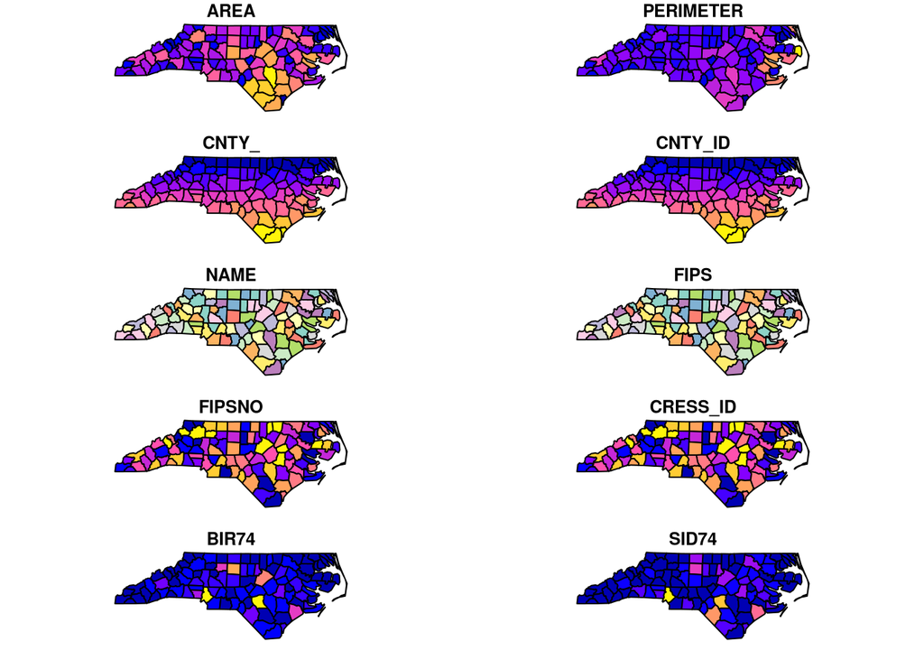

```r
plot(map)
```

## Making maps with R

Mapping with R is commonly done using packages like **ggplot2**, **leaflet**, **mapview**, and **tmap**.

### Mapping with ggplot2

Example:

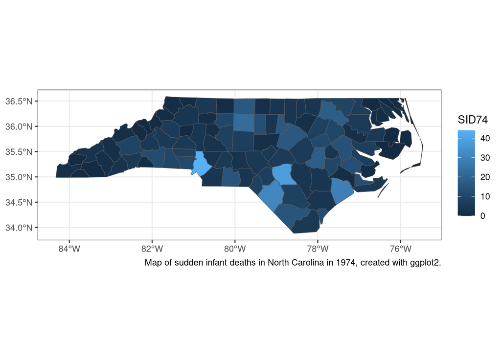

```r
library(sf)
library(ggplot2)

nameshp <- system.file("shape/nc.shp", package = "sf")
map <- st_read(nameshp, quiet = TRUE)
ggplot(map) +
  geom_sf(aes(fill = SID74)) +
  theme_bw() +
  labs(caption = "Map of sudden infant deaths in North Carolina in 1974, created with ggplot2.")
```

The default color scale for discrete variables is `scale_*_hue()`.

Modifying the plot by using a different color scale (viridis scale):

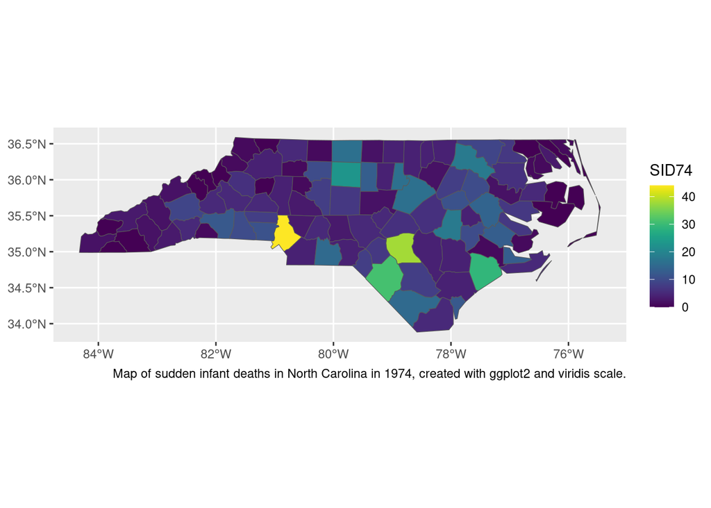

```r
ggplot(map) +
  geom_sf(aes(fill = SID74)) +
  scale_fill_viridis() +
  labs(caption = "Map of sudden infant deaths in North Carolina in 1974, created with ggplot2 and viridis scale.")
```

Saving a plot produced with **ggplot2** is usually done using the `ggsave()` function.

Alternative way to save the plot: first specify the device driver (`png`, `pdf`, etc.), printing the plot, then shutting down the device using `dev.off()`.

```r
png("plot.png")
ggplot(map) +
  geom_sf(aes(fill = SID74)) +
  scale_fill_viridis() +
  labs(caption = "Map of sudden infant deaths in North Carolina in 1974, created with ggplot2 and viridis scale.") +
  theme_bw()
dev.off()
```

To create animated or interactive plots, we can use the **gganimate** or **plotly** packages, respectively, in combination with **ggplot2**.

### leaflet

For making interactive maps, **leaflet** is a popular choice. It is an open-source JavaScript-based library.

### Example using leaflet

Checking the current coordinate reference system using `st_crs()`:

```r
st_crs(map)
```

```
## Coordinate Reference System:
##   User input: NAD27
##   wkt:
## GEOGCRS["NAD27",
##     DATUM["North American Datum 1927",
##         ELLIPSOID["Clarke 1866",6378206.4,294.978698213898,
##             LENGTHUNIT["metre",1]]],
##     PRIMEM["Greenwich",0,
##         ANGLEUNIT["degree",0.0174532925199433]],
##     CS[ellipsoidal,2],
##         AXIS["latitude",north,
##             ORDER[1],
##             ANGLEUNIT["degree",0.0174532925199433]],
##         AXIS["longitude",east,
##             ORDER[2],
##             ANGLEUNIT["degree",0.0174532925199433]],
##     ID["EPSG",4267]]
```

Transforming the CRS of our map to ESPG 4326:

```r
map <- st_transform(map, 4326)
st_crs(map)
```

```
## Coordinate Reference System:
##   User input: EPSG:4326
##   wkt:
## GEOGCRS["WGS 84",
##     ENSEMBLE["World Geodetic System 1984 ensemble",
##         MEMBER["World Geodetic System 1984 (Transit)"],
##         MEMBER["World Geodetic System 1984 (G730)"],
##         MEMBER["World Geodetic System 1984 (G873)"],
##         MEMBER["World Geodetic System 1984 (G1150)"],
##         MEMBER["World Geodetic System 1984 (G1674)"],
##         MEMBER["World Geodetic System 1984 (G1762)"],
##         MEMBER["World Geodetic System 1984 (G2139)"],
##         MEMBER["World Geodetic System 1984 (G2296)"],
##         ELLIPSOID["WGS 84",6378137,298.257223563,
##             LENGTHUNIT["metre",1]],
##         ENSEMBLEACCURACY[2.0]],
##     PRIMEM["Greenwich",0,
##         ANGLEUNIT["degree",0.0174532925199433]],
##     CS[ellipsoidal,2],
##         AXIS["geodetic latitude (Lat)",north,
##             ORDER[1],
##             ANGLEUNIT["degree",0.0174532925199433]],
##         AXIS["geodetic longitude (Lon)",east,
##             ORDER[2],
##             ANGLEUNIT["degree",0.0174532925199433]],
##     USAGE[
##         SCOPE["Horizontal component of 3D system."],
##         AREA["World."],
##         BBOX[-90,-180,90,180]],
##     ID["EPSG",4326]]
```

Defining the desired color palette using `colorNumeric()` and plotting the map using `leaflet():

```r
library(leaflet)

pal <- colorNumeric("YlOrRd", domain = map$SID74)

leaflet(map) |>
  addTiles() |>
  addPolygons(
    color = "white", fillColor = ~ pal(SID74),
    fillOpacity = 1
  ) |>
  addLegend(pal = pal, values = ~ SID74, opacity = 1)
```

[interactive chart not shown]

Map of sudden infant deaths in North Carolina in 1974, created with leaflet.

### mapview

The **mapview** package allows users to very quickly create interactive visualizations (useful during EDA).

Example of an interactive map created using `mapview()`:

```r
library(mapview)
mapview(map, zcol = "SID74")
```

[interactive chart not shown]

Adding customizations to `mapview()`:

```r
library(RColorBrewer)
pal <- colorRampPalette(brewer.pal(9, "YlOrRd"))

mapview(
  map,
  zcol = "SID74",
  map.types = "CartoDB.DarkMatter",
  col.regions = pal
)
```

[interactive chart not shown]

The function `sync()` can be used to produce a lattice-like view of multiple maps created with mapview or leaflet, that zoom and pan in a synchronized manner.

Example of maps that feature synchronized panning and zooming:

```r
library(leafsync)

m74 <- mapview(map, zcol = "SID74")
m79 <- mapview(map, zcol = "SID79")

m <- leafsync::sync(m74, m79)
m
```

[interactive chart not shown]

Synchronized maps of sudden infant deaths in North Carolina in 1974 and 1979.

### tmap

The **tmap** package is used to generate thematic maps. To create thematic maps under this package, a base map is first created using the `tm_shape()` function, then layers are added using the `tm_*()` family of functions. Setting the `tmap_mode()` to `"plot"` produces static maps, and setting the former to `"view:` produces interactive maps.

Example using **tmap** to create an interactive map:

```r
library(tmap)

tmap_mode("view")
```

```
## ℹ tmap modes "plot" - "view"
## ℹ toggle with `tmap::ttm()`
```

```r
tm_shape(map) +
  tm_polygons("SID74")
```

[interactive chart not shown]